# Código operacional e motivação

Anahi

14/10/2020

Carregamento de pacotes e omitindo os warnings

Importando o banco de dados

```r
url <- "https://raw.githubusercontent.com/anahibc/Operational-code/main/unifica.csv"
download.file(url, "unifica.csv", mode = "wb")
dados<- read_csv2("unifica.csv")

paged_table(dados)
```

| Presidente | ideologia | data | dia | month | PWR | ACH | AFF | I1 | P1 |
| --- | --- | --- | --- | --- | --- | --- | --- | --- | --- |
| LopezObrador | esquerda | 07/fev | 7 | 2 | 0.009924573 | 0.004366812 | 0.006550218 | 0.5122 | 0.5102 |
| LopezObrador | esquerda | 11/fev | 11 | 2 | 0.011318619 | 0.009620826 | 0.008866252 | 0.7273 | 0.3631 |
| LopezObrador | esquerda | 14/fev | 14 | 2 | 0.017730496 | 0.006619385 | 0.006855792 | 0.3191 | 0.3659 |
| LopezObrador | esquerda | 18/fev | 18 | 2 | 0.019216371 | 0.008984278 | 0.006738208 | 0.6818 | 0.2182 |
| LopezObrador | esquerda | 20/fev | 20 | 2 | 0.015850652 | 0.008277563 | 0.008629799 | 0.6000 | 0.4545 |
| LopezObrador | esquerda | 24/fev | 24 | 2 | 0.018976699 | 0.006725919 | 0.007206342 | 0.8519 | 0.3162 |
| LopezObrador | esquerda | 27/fev | 27 | 2 | 0.000000000 | 0.005917160 | 0.000000000 | 0.2800 | 0.4118 |
| LopezObrador | esquerda | 04/mar | 4 | 3 | 0.013839891 | 0.006512890 | 0.008141113 | 0.2381 | 0.3889 |
| LopezObrador | esquerda | 10/mar | 10 | 3 | 0.013398839 | 0.006029477 | 0.007369361 | 0.4000 | 0.3800 |
| LopezObrador | esquerda | 12/mar | 12 | 3 | 0.002708192 | 0.008124577 | 0.005416385 | 0.8947 | 0.5484 |

[output cut: 160 more lines]

```r
hdados<-head(dados)
knitr::kable(hdados, col.names = gsub("[.]", " ", names(dados)))
```

| Presidente | ideologia | data | dia | month | PWR | ACH | AFF | I1 | P1 |
| --- | --- | --- | --- | --- | --- | --- | --- | --- | --- |
| LopezObrador | esquerda | 07/fev | 7 | 2 | 0.0099246 | 0.0043668 | 0.0065502 | 0.5122 | 0.5102 |
| LopezObrador | esquerda | 11/fev | 11 | 2 | 0.0113186 | 0.0096208 | 0.0088663 | 0.7273 | 0.3631 |
| LopezObrador | esquerda | 14/fev | 14 | 2 | 0.0177305 | 0.0066194 | 0.0068558 | 0.3191 | 0.3659 |
| LopezObrador | esquerda | 18/fev | 18 | 2 | 0.0192164 | 0.0089843 | 0.0067382 | 0.6818 | 0.2182 |
| LopezObrador | esquerda | 20/fev | 20 | 2 | 0.0158507 | 0.0082776 | 0.0086298 | 0.6000 | 0.4545 |
| LopezObrador | esquerda | 24/fev | 24 | 2 | 0.0189767 | 0.0067259 | 0.0072063 | 0.8519 | 0.3162 |

Convertendo Presidente e ideologia em variáveis categóricas

```r
dados$Presidente=as.factor(dados$Presidente)
dados$ideologia=as.factor(dados$ideologia)
```

```r
#Renomeando a coluna de ideologia politica - simplificando os niveis

df_menor <- dados %>%
  mutate(alinhamento = case_when(ideologia == "esquerda" ~ "esquerda",
                              ideologia == "centro esquerda" ~ "esquerda",
                              ideologia == "centro direita" ~ "direita",
                              ideologia == "direita" ~ "direita"))

df_menor$alinhamento<-as.factor(df_menor$alinhamento)

df_menor
```

```
## # A tibble: 170 x 11
##    Presidente ideologia data    dia month     PWR     ACH     AFF    I1    P1
##    <fct>      <fct>     <chr> <dbl> <dbl>   <dbl>   <dbl>   <dbl> <dbl> <dbl>
##  1 LopezObra~ esquerda  07/f~     7     2 0.00992 0.00437 0.00655 0.512 0.510
##  2 LopezObra~ esquerda  11/f~    11     2 0.0113  0.00962 0.00887 0.727 0.363
##  3 LopezObra~ esquerda  14/f~    14     2 0.0177  0.00662 0.00686 0.319 0.366
##  4 LopezObra~ esquerda  18/f~    18     2 0.0192  0.00898 0.00674 0.682 0.218
##  5 LopezObra~ esquerda  20/f~    20     2 0.0159  0.00828 0.00863 0.6   0.454
##  6 LopezObra~ esquerda  24/f~    24     2 0.0190  0.00673 0.00721 0.852 0.316
##  7 LopezObra~ esquerda  27/f~    27     2 0       0.00592 0       0.28  0.412
##  8 LopezObra~ esquerda  04/m~     4     3 0.0138  0.00651 0.00814 0.238 0.389
##  9 LopezObra~ esquerda  10/m~    10     3 0.0134  0.00603 0.00737 0.4   0.38
## 10 LopezObra~ esquerda  12/m~    12     3 0.00271 0.00812 0.00542 0.895 0.548
## # ... with 160 more rows, and 1 more variable: alinhamento <fct>
```

```r
# Renomeando mês
df_menor <- df_menor%>%rename(mes = month)

#Convertendo as variÃ¡veis em categorias para o banco de dados menor
df_menor$mes<-as.factor(df_menor$mes)
```

```r
#Selecionando variaveis para df_menor como tibble
df_menor=as_tibble(df_menor)
```

Estrutura dos dados

```r
str(df_menor)
```

```
## tibble [170 x 11] (S3: tbl_df/tbl/data.frame)
##  $ Presidente : Factor w/ 4 levels "Bolsonaro","Duque",..: 4 4 4 4 4 4 4 4 4 4 ...
##  $ ideologia  : Factor w/ 4 levels "centro direita",..: 4 4 4 4 4 4 4 4 4 4 ...
##  $ data       : chr [1:170] "07/fev" "11/fev" "14/fev" "18/fev" ...
##  $ dia        : num [1:170] 7 11 14 18 20 24 27 4 10 12 ...
##  $ mes        : Factor w/ 7 levels "2","3","4","5",..: 1 1 1 1 1 1 1 2 2 2 ...
##  $ PWR        : num [1:170] 0.00992 0.01132 0.01773 0.01922 0.01585 ...
##  $ ACH        : num [1:170] 0.00437 0.00962 0.00662 0.00898 0.00828 ...
##  $ AFF        : num [1:170] 0.00655 0.00887 0.00686 0.00674 0.00863 ...
##  $ I1         : num [1:170] 0.512 0.727 0.319 0.682 0.6 ...
##  $ P1         : num [1:170] 0.51 0.363 0.366 0.218 0.455 ...
##  $ alinhamento: Factor w/ 2 levels "direita","esquerda": 2 2 2 2 2 2 2 2 2 2 ...
##  - attr(*, "spec")=
##   .. cols(
##   ..   Presidente = col_character(),
##   ..   ideologia = col_character(),
##   ..   data = col_character(),
##   ..   dia = col_double(),
##   ..   month = col_double(),
##   ..   PWR = col_double(),
##   ..   ACH = col_double(),
##   ..   AFF = col_double(),
##   ..   I1 = col_double(),
##   ..   P1 = col_double()
##   .. )
```

*Análise exploratória de dados*

```r
print(summarytools::dfSummary(df_menor), style = 'grid', graph.magnif = 0.75, valid.col = FALSE, tmp.img.dir = "/tmp", method = 'render')
```

Data Frame Summary

df_menor

**Dimensions**: 170 x 11  
**Duplicates**: 0

| **No** | **Variable** | **Stats / Values** | **Freqs (% of Valid)** | **Graph** | **Missing** |
| --- | --- | --- | --- | --- | --- |
| 1 | Presidente [factor] | 1. Bolsonaro 2. Duque 3. Fernandez 4. LopezObrador | 27 ( 15.9% ) 54 ( 31.8% ) 38 ( 22.4% ) 51 ( 30.0% ) |  | 0 (0%) |
| 2 | ideologia [factor] | 1. centro direita 2. centro esquerda 3. direita 4. esquerda | 54 ( 31.8% ) 38 ( 22.4% ) 27 ( 15.9% ) 51 ( 30.0% ) |  | 0 (0%) |
| 3 | data [character] | 1. 10/mar 2. 25/jun 3. 01/abr 4. 04/mar 5. 09/jun 6. 11/fev 7. 14/fev 8. 15/abr 9. 15/mai 10. 20/fev [ 98 others ] | 4 ( 2.4% ) 4 ( 2.4% ) 3 ( 1.8% ) 3 ( 1.8% ) 3 ( 1.8% ) 3 ( 1.8% ) 3 ( 1.8% ) 3 ( 1.8% ) 3 ( 1.8% ) 3 ( 1.8% ) 138 ( 81.2% ) |  | 0 (0%) |
| 4 | dia [numeric] | Mean (sd) : 16 (8.5) min < med < max: 1 < 16 < 31 IQR (CV) : 12.8 (0.5) | 31 distinct values |  | 0 (0%) |
| 5 | mes [factor] | 1. 2 2. 3 3. 4 4. 5 5. 6 6. 7 7. 8 | 22 ( 12.9% ) 30 ( 17.6% ) 25 ( 14.7% ) 29 ( 17.1% ) 32 ( 18.8% ) 31 ( 18.2% ) 1 ( 0.6% ) |  | 0 (0%) |
| 6 | PWR [numeric] | Mean (sd) : 0 (0) min < med < max: 0 < 0 < 0 IQR (CV) : 0 (0.6) | 165 distinct values |  | 0 (0%) |
| 7 | ACH [numeric] | Mean (sd) : 0 (0) min < med < max: 0 < 0 < 0 IQR (CV) : 0 (0.4) | 166 distinct values |  | 0 (0%) |
| 8 | AFF [numeric] | Mean (sd) : 0 (0) min < med < max: 0 < 0 < 0 IQR (CV) : 0 (0.5) | 166 distinct values |  | 0 (0%) |
| 9 | I1 [numeric] | Mean (sd) : 0.6 (0.3) min < med < max: -0.1 < 0.6 < 1 IQR (CV) : 0.3 (0.4) | 90 distinct values |  | 0 (0%) |
| 10 | P1 [numeric] | Mean (sd) : 0.5 (0.2) min < med < max: 0.1 < 0.5 < 1 IQR (CV) : 0.2 (0.4) | 123 distinct values |  | 0 (0%) |
| 11 | alinhamento [factor] | 1. direita 2. esquerda | 81 ( 47.6% ) 89 ( 52.3% ) |  | 0 (0%) |

Generated by summarytools 0.9.6 ([R](https://www.r-project.org/) version 4.0.0)  
2020-10-16

```r
mydata <- summarytools::descr(df_menor)

print(mydata , method = 'render')
```

Descriptive Statistics

df_menor

**N**: 170

|  | ACH | AFF | dia | I1 | P1 | PWR |
| --- | --- | --- | --- | --- | --- | --- |
| **Mean** | 0.01 | 0.01 | 15.99 | 0.65 | 0.50 | 0.01 |
| **Std.Dev** | 0.00 | 0.01 | 8.50 | 0.25 | 0.19 | 0.00 |
| **Min** | 0.00 | 0.00 | 1.00 | -0.14 | 0.06 | 0.00 |
| **Q1** | 0.01 | 0.01 | 10.00 | 0.50 | 0.38 | 0.00 |
| **Median** | 0.01 | 0.01 | 16.00 | 0.64 | 0.48 | 0.01 |
| **Q3** | 0.01 | 0.02 | 23.00 | 0.85 | 0.60 | 0.01 |
| **Max** | 0.02 | 0.04 | 31.00 | 1.00 | 1.00 | 0.03 |
| **MAD** | 0.00 | 0.01 | 8.90 | 0.26 | 0.16 | 0.00 |
| **IQR** | 0.00 | 0.01 | 12.75 | 0.34 | 0.22 | 0.01 |
| **CV** | 0.40 | 0.50 | 0.53 | 0.39 | 0.38 | 0.58 |
| **Skewness** | 0.94 | 0.99 | -0.05 | -0.39 | 0.35 | 1.01 |
| **SE.Skewness** | 0.19 | 0.19 | 0.19 | 0.19 | 0.19 | 0.19 |
| **Kurtosis** | 1.02 | 1.34 | -1.03 | -0.22 | 0.19 | 0.72 |
| **N.Valid** | 170 | 170 | 170 | 170 | 170 | 170 |
| **Pct.Valid** | 100.00 | 100.00 | 100.00 | 100.00 | 100.00 | 100.00 |

Generated by summarytools 0.9.6 ([R](https://www.r-project.org/) version 4.0.0)  
2020-10-16

**Boxplots e Histograma**

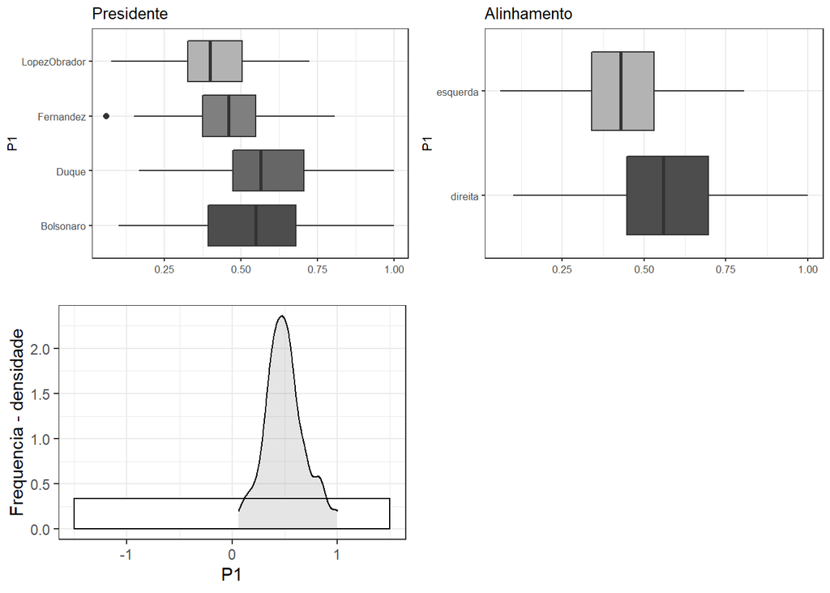

```r
p1 <- ggplot(df_menor, aes(P1, Presidente)) +   # data + x/y-axes
  geom_boxplot(fill=c("grey30","grey40","grey50",  "grey70")) + # def. col.
  theme_bw(base_size = 8)+   # black and white theme
  labs(x = "") +                        # x-axis label
  labs(y = "P1", cex = .75) +   # y-axis label  # y-axis range
  guides(fill = FALSE) +                # no legend
  ggtitle("Presidente")
# title
# plot 2
p2 <- ggplot(df_menor, aes(P1, alinhamento)) +
  geom_boxplot(fill=c("grey30", "grey70")) +
  theme_bw(base_size = 8) +
  labs(x = "") +                              # x-axis label
  labs(y = "P1") +  # y-axis label
  guides(fill = FALSE) +
  ggtitle("Alinhamento")
# plot 3
p3 <- ggplot(df_menor, aes(x = P1)) +
  geom_histogram(aes(y=..density..),    # add density statistic
                 binwidth = 3,         # def. bin width
                 colour = "black",      # def. bar edge colour
                 fill = "white") +      # def. bar col.
  theme_bw() +                        # black-white theme
  geom_density(alpha=.2, fill = "gray50") + # def. col. of overlay
  labs(x = "P1") +
  labs(y = "Frequencia - densidade")
# plot 4
# show plots
grid.arrange(grobs = list(p1, p2, p3), widths = c(1, 1),
             layout_matrix = rbind(c(1, 2), c(3, 4)))
```

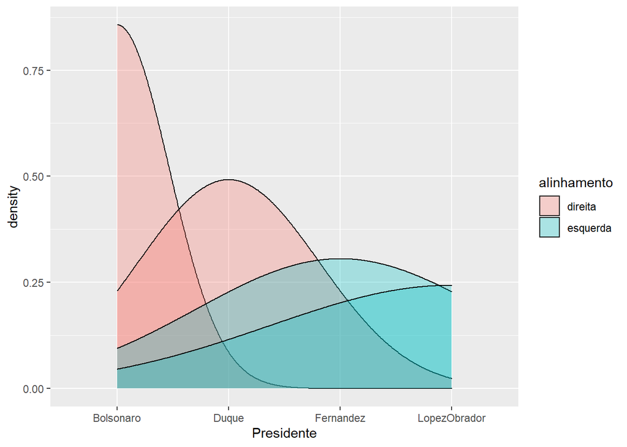

```r
ggplot(df_menor, aes(Presidente, fill = alinhamento)) +
  geom_density(alpha = 0.3)
```

*Observação*

O histograma para a variável resposta P1 está limitado entre 0 e 1, indicando que a distribuição normal não se mostra adequada, de modo que seria recomendado um ajuste por meio de modelo lineares generalizados. Seriam utilizados dados para proporção e limitados ao intervalo 0 e 1, sendo uma possível estratégia a distribuição beta. No entanto, optou-se por não realizar o ajuste que exige mais acurácia.

```r
#correlação

df=df_menor[,-c(1:5,11)]
str(df)
```

```
## tibble [170 x 5] (S3: tbl_df/tbl/data.frame)
##  $ PWR: num [1:170] 0.00992 0.01132 0.01773 0.01922 0.01585 ...
##  $ ACH: num [1:170] 0.00437 0.00962 0.00662 0.00898 0.00828 ...
##  $ AFF: num [1:170] 0.00655 0.00887 0.00686 0.00674 0.00863 ...
##  $ I1 : num [1:170] 0.512 0.727 0.319 0.682 0.6 ...
##  $ P1 : num [1:170] 0.51 0.363 0.366 0.218 0.455 ...
##  - attr(*, "spec")=
##   .. cols(
##   ..   Presidente = col_character(),
##   ..   ideologia = col_character(),
##   ..   data = col_character(),
##   ..   dia = col_double(),
##   ..   month = col_double(),
##   ..   PWR = col_double(),
##   ..   ACH = col_double(),
##   ..   AFF = col_double(),
##   ..   I1 = col_double(),
##   ..   P1 = col_double()
##   .. )
```

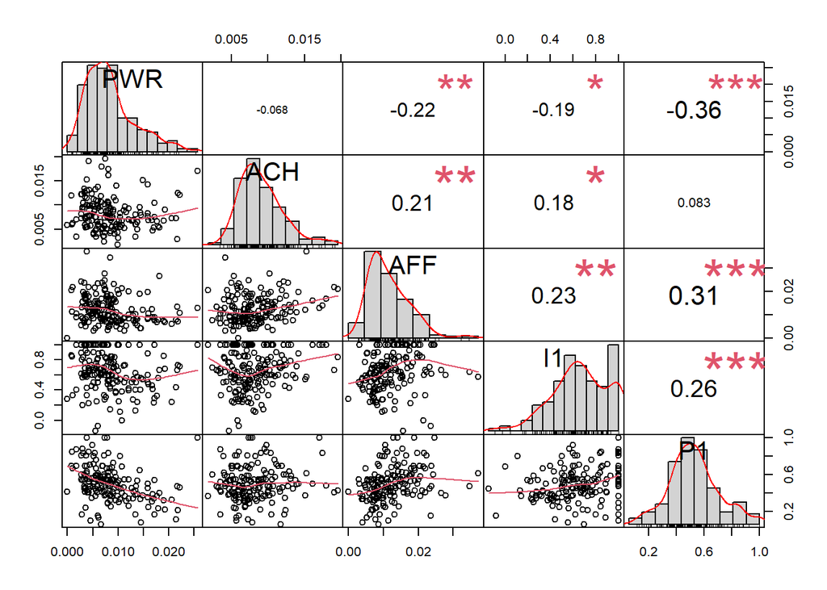

```r
chart.Correlation(df, histogram=TRUE, pch=19)
```

*Primeiro modelo*

Inicialmente foi ajustado um modelo completo com todas as variáveis que podem influenciar a variável P1, porém neste modelo houve o acréscimo dos efeitos de interação entre os presidentes e as variáveis independentes (PWR, AFF, ACH, I1).

```r
model=lm(P1~Presidente+PWR+AFF+ACH+I1+mes+Presidente*PWR+Presidente*AFF+Presidente*ACH+Presidente*I1, data=df_menor)
```

A partir deste modelo foi feita uma seleção de variáveis por meio da técnica de stepwise.

```r
model1=step(model)
```

```
## Start:  AIC=-598.56
## P1 ~ Presidente + PWR + AFF + ACH + I1 + mes + Presidente * PWR +
##     Presidente * AFF + Presidente * ACH + Presidente * I1
##
##                  Df Sum of Sq    RSS     AIC
## - mes             6  0.182738 3.8850 -602.37
## - Presidente:I1   3  0.069669 3.7719 -601.40
## - Presidente:ACH  3  0.129564 3.8318 -598.72
## <none>                        3.7023 -598.56
## - Presidente:AFF  3  0.159136 3.8614 -597.41
## - Presidente:PWR  3  0.175658 3.8779 -596.68
##
## Step:  AIC=-602.37
## P1 ~ Presidente + PWR + AFF + ACH + I1 + Presidente:PWR + Presidente:AFF +
##     Presidente:ACH + Presidente:I1
##
##                  Df Sum of Sq    RSS     AIC
## - Presidente:I1   3  0.063036 3.9481 -605.64
## - Presidente:ACH  3  0.123563 4.0086 -603.05
## <none>                        3.8850 -602.37
## - Presidente:PWR  3  0.162910 4.0479 -601.39
## - Presidente:AFF  3  0.167271 4.0523 -601.21
##
## Step:  AIC=-605.64
## P1 ~ Presidente + PWR + AFF + ACH + I1 + Presidente:PWR + Presidente:AFF +
##     Presidente:ACH
##
##                  Df Sum of Sq    RSS     AIC
## - I1              1  0.045306 3.9934 -605.70
## <none>                        3.9481 -605.64
## - Presidente:ACH  3  0.142686 4.0907 -605.60
## - Presidente:PWR  3  0.166994 4.1150 -604.60
## - Presidente:AFF  3  0.222110 4.1702 -602.33
##
## Step:  AIC=-605.7
## P1 ~ Presidente + PWR + AFF + ACH + Presidente:PWR + Presidente:AFF +
##     Presidente:ACH
##
##                  Df Sum of Sq    RSS     AIC
## - Presidente:ACH  3   0.14090 4.1343 -605.80
## <none>                        3.9934 -605.70
## - Presidente:PWR  3   0.18227 4.1756 -604.11
## - Presidente:AFF  3   0.23162 4.2250 -602.11
##
## Step:  AIC=-605.8
## P1 ~ Presidente + PWR + AFF + ACH + Presidente:PWR + Presidente:AFF
##
##                  Df Sum of Sq    RSS     AIC
## - ACH             1  0.006779 4.1410 -607.52
## <none>                        4.1343 -605.80
## - Presidente:PWR  3  0.220860 4.3551 -602.96
## - Presidente:AFF  3  0.275346 4.4096 -600.84
##
## Step:  AIC=-607.52
## P1 ~ Presidente + PWR + AFF + Presidente:PWR + Presidente:AFF
##
##                  Df Sum of Sq    RSS     AIC
## <none>                        4.1410 -607.52
## - Presidente:PWR  3   0.21679 4.3578 -604.85
## - Presidente:AFF  3   0.27061 4.4117 -602.76
```

```r
summary(model1)
```

```
##
## Call:
## lm(formula = P1 ~ Presidente + PWR + AFF + Presidente:PWR + Presidente:AFF,
##     data = df_menor)
##
## Residuals:
##      Min       1Q   Median       3Q      Max
## -0.46419 -0.08971  0.00478  0.09712  0.38922
##
## Coefficients:
##                            Estimate Std. Error t value Pr(>|t|)
## (Intercept)                  0.1853     0.1157   1.602 0.111149
## PresidenteDuque              0.4974     0.1325   3.755 0.000243 ***
## PresidenteFernandez          0.2749     0.1447   1.899 0.059344 .
## PresidenteLopezObrador       0.2702     0.1443   1.873 0.062890 .
## PWR                          8.5122     6.3185   1.347 0.179844
## AFF                         19.0044     5.3269   3.568 0.000477 ***
## PresidenteDuque:PWR        -20.9588     9.2614  -2.263 0.024996 *
## PresidenteFernandez:PWR    -18.6296     8.6366  -2.157 0.032513 *
## PresidenteLopezObrador:PWR -21.1907     7.9942  -2.651 0.008849 **
## PresidenteDuque:AFF        -20.2641     6.5144  -3.111 0.002215 **
## PresidenteFernandez:AFF    -13.2532     6.7534  -1.962 0.051466 .
## PresidenteLopezObrador:AFF  -7.2871     9.0030  -0.809 0.419493
## ---
## Signif. codes:  0 '***' 0.001 '**' 0.01 '*' 0.05 '.' 0.1 ' ' 1
##
## Residual standard error: 0.1619 on 158 degrees of freedom
## Multiple R-squared:  0.325,  Adjusted R-squared:  0.278
## F-statistic: 6.916 on 11 and 158 DF,  p-value: 1.808e-09
```

*Segundo modelo*

Antes de serem analisados os resíduos e as outras métricas de ajustes envolvidas na regressão, optou-se por realizar um segundo modelo via proposta de Collet (1994). Nesta proposta, há mais liberdade para o pesquisador, as variaveis são retiradas conforme com o valor do P-Valor e recolocadas até que se alcance um modelo com todas a variaveis significativas. Além da autonomia do pesquisador, o método de Collet evita um erro comum no método automático que pode eliminar variáveis importantes para o modelo.

```r
m1=lm(P1~Presidente+PWR+AFF+ACH+I1+mes+Presidente*ACH+Presidente*AFF+Presidente*PWR, data=df_menor)

#resumo do modelo m1 de Collet
summary(m1)
```

```
##
## Call:
## lm(formula = P1 ~ Presidente + PWR + AFF + ACH + I1 + mes + Presidente *
##     ACH + Presidente * AFF + Presidente * PWR, data = df_menor)
##
## Residuals:
##      Min       1Q   Median       3Q      Max
## -0.44261 -0.09280  0.00298  0.09604  0.39294
##
## Coefficients:
##                              Estimate Std. Error t value Pr(>|t|)
## (Intercept)                  0.104990   0.123820   0.848  0.39786
## PresidenteDuque              0.618841   0.150941   4.100 6.81e-05 ***
## PresidenteFernandez          0.391652   0.167025   2.345  0.02037 *
## PresidenteLopezObrador       0.367810   0.173622   2.118  0.03582 *
## PWR                          6.336701   6.349732   0.998  0.31994
## AFF                         16.089982   5.465903   2.944  0.00377 **
## ACH                         11.895174   7.262693   1.638  0.10359
## I1                           0.058923   0.054767   1.076  0.28374
## mes3                        -0.068743   0.048892  -1.406  0.16183
## mes4                         0.013456   0.051232   0.263  0.79319
## mes5                         0.002122   0.049672   0.043  0.96598
## mes6                         0.031214   0.047490   0.657  0.51203
## mes7                        -0.003768   0.048956  -0.077  0.93876
## mes8                         0.112116   0.178116   0.629  0.53003
## PresidenteDuque:ACH        -20.021526   9.727022  -2.058  0.04132 *
## PresidenteFernandez:ACH    -21.387544  10.828819  -1.975  0.05013 .
## PresidenteLopezObrador:ACH -18.710227  15.480633  -1.209  0.22875
## PresidenteDuque:AFF        -17.703522   6.638651  -2.667  0.00852 **
## PresidenteFernandez:AFF    -10.099013   7.161619  -1.410  0.16061
## PresidenteLopezObrador:AFF  -2.486182   9.252964  -0.269  0.78854
## PresidenteDuque:PWR        -19.486851   9.330037  -2.089  0.03847 *
## PresidenteFernandez:PWR    -15.449744   8.893263  -1.737  0.08444 .
## PresidenteLopezObrador:PWR -19.678796   8.106465  -2.428  0.01641 *
## ---
## Signif. codes:  0 '***' 0.001 '**' 0.01 '*' 0.05 '.' 0.1 ' ' 1
##
## Residual standard error: 0.1602 on 147 degrees of freedom
## Multiple R-squared:  0.3852, Adjusted R-squared:  0.2932
## F-statistic: 4.186 on 22 and 147 DF,  p-value: 6.994e-08
```

```r
#resumo do modelo m2 de Collet
summary(m2 <- update(m1, . ~ . - mes))
```

```
##
## Call:
## lm(formula = P1 ~ Presidente + PWR + AFF + ACH + I1 + Presidente:ACH +
##     Presidente:AFF + Presidente:PWR, data = df_menor)
##
## Residuals:
##      Min       1Q   Median       3Q      Max
## -0.44795 -0.08295  0.00347  0.09273  0.38565
##
## Coefficients:
##                             Estimate Std. Error t value Pr(>|t|)
## (Intercept)                  0.09199    0.12296   0.748  0.45553
## PresidenteDuque              0.60403    0.14841   4.070 7.51e-05 ***
## PresidenteFernandez          0.38432    0.15527   2.475  0.01441 *
## PresidenteLopezObrador       0.36097    0.17264   2.091  0.03819 *
## PWR                          6.80553    6.33610   1.074  0.28447
## AFF                         16.35533    5.43099   3.011  0.00304 **
## ACH                         11.34079    7.19657   1.576  0.11712
## I1                           0.07111    0.05367   1.325  0.18713
## PresidenteDuque:ACH        -18.16964    9.66112  -1.881  0.06191 .
## PresidenteFernandez:ACH    -22.47907   10.53356  -2.134  0.03443 *
## PresidenteLopezObrador:ACH -18.27878   15.23255  -1.200  0.23200
## PresidenteDuque:AFF        -17.82092    6.56323  -2.715  0.00738 **
## PresidenteFernandez:AFF     -8.69308    6.95372  -1.250  0.21316
## PresidenteLopezObrador:AFF  -4.12838    9.05851  -0.456  0.64922
## PresidenteDuque:PWR        -19.31830    9.24156  -2.090  0.03824 *
## PresidenteFernandez:PWR    -16.15981    8.63648  -1.871  0.06324 .
## PresidenteLopezObrador:PWR -18.53041    8.02867  -2.308  0.02234 *
## ---
## Signif. codes:  0 '***' 0.001 '**' 0.01 '*' 0.05 '.' 0.1 ' ' 1
##
## Residual standard error: 0.1606 on 153 degrees of freedom
## Multiple R-squared:  0.3565, Adjusted R-squared:  0.2892
## F-statistic: 5.297 on 16 and 153 DF,  p-value: 8.544e-09
```

```r
#resumo do modelo m3 de Collet
summary(m3 <- update(m2, . ~ . - I1))
```

```
##
## Call:
## lm(formula = P1 ~ Presidente + PWR + AFF + ACH + Presidente:ACH +
##     Presidente:AFF + Presidente:PWR, data = df_menor)
##
## Residuals:
##      Min       1Q   Median       3Q      Max
## -0.44201 -0.09144  0.00335  0.09051  0.39957
##
## Coefficients:
##                            Estimate Std. Error t value Pr(>|t|)
## (Intercept)                  0.1239     0.1209   1.025  0.30675
## PresidenteDuque              0.6175     0.1484   4.160 5.27e-05 ***
## PresidenteFernandez          0.3957     0.1554   2.546  0.01188 *
## PresidenteLopezObrador       0.3704     0.1729   2.142  0.03378 *
## PWR                          7.0151     6.3497   1.105  0.27097
## AFF                         17.3668     5.3903   3.222  0.00155 **
## ACH                         11.9135     7.2012   1.654  0.10009
## PresidenteDuque:ACH        -18.5360     9.6808  -1.915  0.05738 .
## PresidenteFernandez:ACH    -22.0351    10.5540  -2.088  0.03846 *
## PresidenteLopezObrador:ACH -17.7756    15.2651  -1.164  0.24604
## PresidenteDuque:AFF        -18.5655     6.5552  -2.832  0.00524 **
## PresidenteFernandez:AFF    -10.0179     6.8983  -1.452  0.14847
## PresidenteLopezObrador:AFF  -5.3754     9.0316  -0.595  0.55260
## PresidenteDuque:PWR        -19.7060     9.2596  -2.128  0.03491 *
## PresidenteFernandez:PWR    -16.4145     8.6555  -1.896  0.05978 .
## PresidenteLopezObrador:PWR -19.6514     8.0035  -2.455  0.01519 *
## ---
## Signif. codes:  0 '***' 0.001 '**' 0.01 '*' 0.05 '.' 0.1 ' ' 1
##
## Residual standard error: 0.161 on 154 degrees of freedom
## Multiple R-squared:  0.3491, Adjusted R-squared:  0.2857
## F-statistic: 5.506 on 15 and 154 DF,  p-value: 7.327e-09
```

*Modelo mais robusto pela proposta de Collet foi o m3*.

Para tomar a decisão entre o modelo stepwise e o modelo m3 de Collet, Foi realizada a criação de uma tabela comparativa dos modelos finais de ambos os métodos. Apesar de ambos serem muito próximos, o modelo m3 de Collet tem maior R² ajustado e o valor de AIC está dentro de uma diferença em um intervalo muito pequeno de AIC. Ademais para o estudo realizado é importante que o modelo conste de das variáveis AFF, ACH e PWR, uma vez que são fundamentais para a análise do presente trabalho.

```r
metric1=cbind("Modelo_stepwise",extractAIC(model1)[2], summary(model1)$adj.r.squared*100)
metric2=cbind("Modelo_collet",extractAIC(m3)[2], summary(m3)$adj.r.squared*100)
AICs=rbind(metric1,metric2)

knitr::kable(AICs, col.names = c("Modelo","AIC","RÂ² ajustado"))
```

| Modelo | AIC | RÂ² ajustado |
| --- | --- | --- |
| Modelo_stepwise | -607.524620816078 | 27.8024226113127 |
| Modelo_collet | -605.698113095277 | 28.5688348141149 |

*Detecção de outlier* Depois de implementar a regressão múltipla, é necessário verificar se o modelo *m3* apresenta outliers. Em seguida, é realizado o diagnóstico, testando se a remoção de observações discrepantes diminui desproporcionalmente o ajuste do modelo, ou se aperfeiçoa o modelo.

*Gráficos de diagnóstico* Em seguida são gerados os gráficos de verificação de homogeneidade de variâncias, de verificação de normalidade e relação de pontos influentes e outliers.

*Análise de resíduos* Foi realizada a análise de resíduos em que pode-se apontar alguns fatores presentes na análise com respeito aos pressupostos. Primeiro a normalidade não pode ser verificada por meio do qqnorm. Segundo há pontos influentes e outliers que foram identificados logo abaixo. Neste sentido, foi feita a remoção dos valores discrepantes e um novo ajuste.

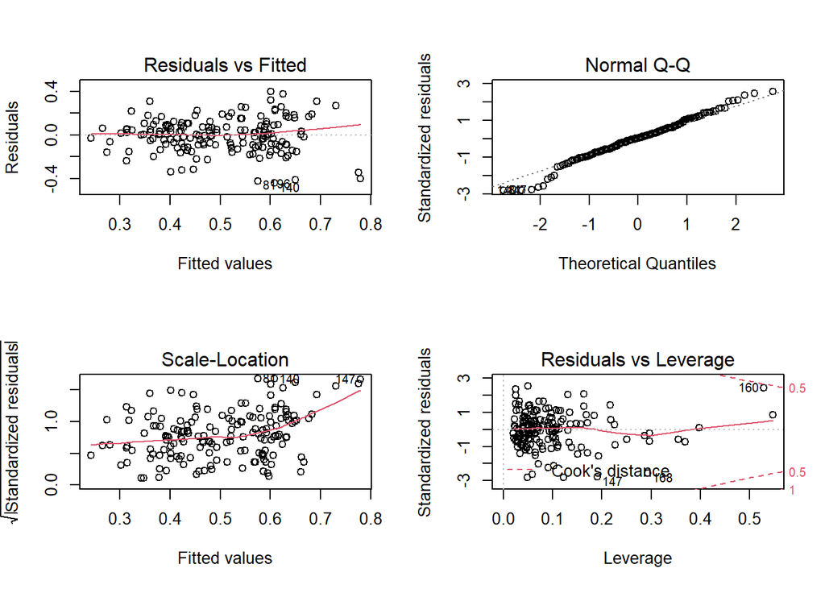

```r
par(mfrow=c(2,2))
plot(m3)
```

```r
par(mfrow=c(1,1))
hnp(m3,how.many.out = TRUE,print.on = TRUE)#retirar pontos
```

```
## Gaussian model (lm object)
```

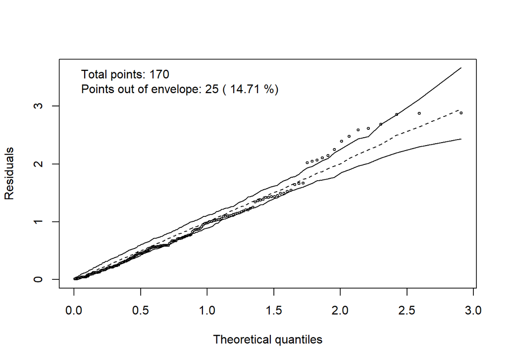

É importante verificar que de acordo half norm plot - hnp, mais de 10% das observações estão fora das bandas de confiança indicando que não há normalidade dos resíduos. O que leva a fazer uma checagem mais aprofundada sobre pontos de alavanca e outliers, para uma possível remoção.

```r
cooksd <- cooks.distance(m3)
```

Pontos influentes

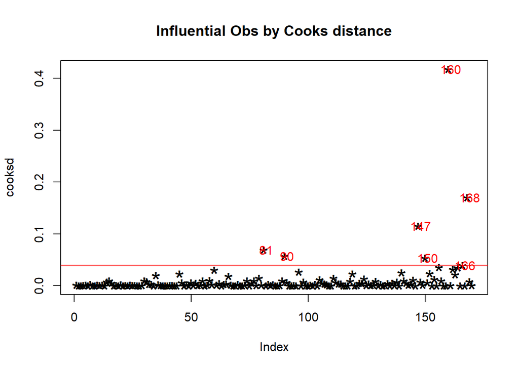

```
## integer(0)
```

```r
plot(cooksd, pch="*", cex=2, main="Influential Obs by Cooks distance")+
 abline(h = 4*mean(cooksd, na.rm=T), col="red")+
  text(x=1:length(cooksd)+1, y=cooksd, labels=ifelse(cooksd>4*mean(cooksd,     na.rm=T),names(cooksd),""), col="red")
```

```r
influential <- as.numeric(names(cooksd)[(cooksd > 4*mean(cooksd, na.rm=T))])  # influential row numbers
head(df_menor[influential, ])  # influential observations.
```

```
## # A tibble: 6 x 11
##   Presidente ideologia data    dia mes       PWR     ACH     AFF      I1    P1
##   <fct>      <fct>     <chr> <dbl> <fct>   <dbl>   <dbl>   <dbl>   <dbl> <dbl>
## 1 Fernandez  centro e~ 03/j~     3 7     0.00604 0.00604 0.0236  -0.0769 0.15
## 2 Duque      centro d~ 05/f~     5 2     0.0222  0.0120  0.0106   0.714  0.462
## 3 Bolsonaro  direita   11/f~    11 2     0.00731 0.0102  0.0278   0.6    0.375
## 4 Bolsonaro  direita   20/f~    20 2     0.00835 0.00752 0.00501  0.524  0.667
## 5 Bolsonaro  direita   08/j~     8 6     0.0256  0.0171  0.0128   1      1
## 6 Bolsonaro  direita   25/j~    25 6     0.00741 0.00741 0.0247   1      1
## # ... with 1 more variable: alinhamento <fct>
```

```r
car::outlierTest(m3)
```

```
## No Studentized residuals with Bonferroni p < 0.05
## Largest |rstudent|:
##    rstudent unadjusted p-value Bonferroni p
## 81  -2.8822          0.0045175      0.76798
```

```r
outliers <- boxplot(m3$residuals, plot=FALSE)$out
outliers
```

```
##         81         96        129        140        147        163
## -0.4248069 -0.4121649  0.3749278 -0.4420136 -0.4045596  0.3995679
```

```r
df_menor[which(m3$residuals %in% outliers),]
```

```
## # A tibble: 6 x 11
##   Presidente ideologia data    dia mes       PWR     ACH     AFF      I1    P1
##   <fct>      <fct>     <chr> <dbl> <fct>   <dbl>   <dbl>   <dbl>   <dbl> <dbl>
## 1 Fernandez  centro e~ 03/j~     3 7     0.00604 0.00604 0.0236  -0.0769 0.15
## 2 Duque      centro d~ 12/m~    12 3     0.00360 0.00540 0.00810  1      0.238
## 3 Duque      centro d~ 17/j~    17 6     0.00384 0.00767 0.0141   1      1
## 4 Duque      centro d~ 23/j~    23 7     0.00282 0.0122  0.0132   0.8    0.167
## 5 Bolsonaro  direita   11/f~    11 2     0.00731 0.0102  0.0278   0.6    0.375
## 6 Bolsonaro  direita   17/j~    17 7     0.00786 0.00786 0.0189   1      1
## # ... with 1 more variable: alinhamento <fct>
```

Remoção de Outlier

```r
df_menor_out <- df_menor[-which(m3$residuals %in% outliers),]
df_menor_out
```

```
## # A tibble: 164 x 11
##    Presidente ideologia data    dia mes       PWR     ACH     AFF    I1    P1
##    <fct>      <fct>     <chr> <dbl> <fct>   <dbl>   <dbl>   <dbl> <dbl> <dbl>
##  1 LopezObra~ esquerda  07/f~     7 2     0.00992 0.00437 0.00655 0.512 0.510
##  2 LopezObra~ esquerda  11/f~    11 2     0.0113  0.00962 0.00887 0.727 0.363
##  3 LopezObra~ esquerda  14/f~    14 2     0.0177  0.00662 0.00686 0.319 0.366
##  4 LopezObra~ esquerda  18/f~    18 2     0.0192  0.00898 0.00674 0.682 0.218
##  5 LopezObra~ esquerda  20/f~    20 2     0.0159  0.00828 0.00863 0.6   0.454
##  6 LopezObra~ esquerda  24/f~    24 2     0.0190  0.00673 0.00721 0.852 0.316
##  7 LopezObra~ esquerda  27/f~    27 2     0       0.00592 0       0.28  0.412
##  8 LopezObra~ esquerda  04/m~     4 3     0.0138  0.00651 0.00814 0.238 0.389
##  9 LopezObra~ esquerda  10/m~    10 3     0.0134  0.00603 0.00737 0.4   0.38
## 10 LopezObra~ esquerda  12/m~    12 3     0.00271 0.00812 0.00542 0.895 0.548
## # ... with 154 more rows, and 1 more variable: alinhamento <fct>
```

Os novos gráficos de diagnóstico não indicam outliers que requerem remoção, apenas alguns pontos influentes que não serão removidos.

*Reajustando o modelo m3 sem outliers*

Segunda Modelagem *m3* sem os pontos influentes e outiliers previamente retirados

```r
m1=lm(P1~Presidente+PWR+AFF+ACH+I1+mes+Presidente*ACH+Presidente*AFF+Presidente*PWR, data=df_menor_out)
summary(m1)
```

```
##
## Call:
## lm(formula = P1 ~ Presidente + PWR + AFF + ACH + I1 + mes + Presidente *
##     ACH + Presidente * AFF + Presidente * PWR, data = df_menor_out)
##
## Residuals:
##      Min       1Q   Median       3Q      Max
## -0.39310 -0.09267  0.00035  0.08821  0.33822
##
## Coefficients:
##                              Estimate Std. Error t value Pr(>|t|)
## (Intercept)                 5.146e-02  1.116e-01   0.461 0.645430
## PresidenteDuque             7.488e-01  1.389e-01   5.392 2.87e-07 ***
## PresidenteFernandez         5.182e-01  1.524e-01   3.399 0.000879 ***
## PresidenteLopezObrador      4.690e-01  1.567e-01   2.994 0.003254 **
## PWR                         7.303e+00  5.602e+00   1.304 0.194461
## AFF                         2.181e+01  5.359e+00   4.069 7.82e-05 ***
## ACH                         1.355e+01  6.428e+00   2.107 0.036850 *
## I1                          9.261e-03  5.092e-02   0.182 0.855925
## mes3                       -7.492e-02  4.441e-02  -1.687 0.093843 .
## mes4                       -1.461e-02  4.622e-02  -0.316 0.752419
## mes5                       -2.439e-02  4.486e-02  -0.544 0.587511
## mes6                       -6.754e-04  4.316e-02  -0.016 0.987536
## mes7                       -1.748e-02  4.563e-02  -0.383 0.702288
## mes8                        1.133e-01  1.572e-01   0.721 0.471986
## PresidenteDuque:ACH        -2.026e+01  8.662e+00  -2.339 0.020720 *
## PresidenteFernandez:ACH    -2.749e+01  9.642e+00  -2.851 0.005008 **
## PresidenteLopezObrador:ACH -1.967e+01  1.367e+01  -1.439 0.152388
## PresidenteDuque:AFF        -2.410e+01  6.276e+00  -3.841 0.000185 ***
## PresidenteFernandez:AFF    -1.298e+01  6.899e+00  -1.881 0.061979 .
## PresidenteLopezObrador:AFF -8.425e+00  8.443e+00  -0.998 0.320080
## PresidenteDuque:PWR        -2.308e+01  8.290e+00  -2.784 0.006099 **
## PresidenteFernandez:PWR    -1.788e+01  7.852e+00  -2.277 0.024305 *
## PresidenteLopezObrador:PWR -2.131e+01  7.164e+00  -2.974 0.003455 **
## ---
## Signif. codes:  0 '***' 0.001 '**' 0.01 '*' 0.05 '.' 0.1 ' ' 1
##
## Residual standard error: 0.1412 on 141 degrees of freedom
## Multiple R-squared:  0.4709, Adjusted R-squared:  0.3884
## F-statistic: 5.705 on 22 and 141 DF,  p-value: 3.583e-11
```

```r
summary(m2 <- update(m1, . ~ . - mes))
```

```
##
## Call:
## lm(formula = P1 ~ Presidente + PWR + AFF + ACH + I1 + Presidente:ACH +
##     Presidente:AFF + Presidente:PWR, data = df_menor_out)
##
## Residuals:
##      Min       1Q   Median       3Q      Max
## -0.38305 -0.09298  0.00309  0.08932  0.35432
##
## Coefficients:
##                             Estimate Std. Error t value Pr(>|t|)
## (Intercept)                  0.03572    0.11086   0.322 0.747776
## PresidenteDuque              0.72867    0.13454   5.416 2.43e-07 ***
## PresidenteFernandez          0.47915    0.13934   3.439 0.000760 ***
## PresidenteLopezObrador       0.44778    0.15421   2.904 0.004256 **
## PWR                          7.56340    5.56840   1.358 0.176458
## AFF                         21.53491    5.24923   4.102 6.75e-05 ***
## ACH                         12.74086    6.33027   2.013 0.045973 *
## I1                           0.01859    0.04970   0.374 0.708886
## PresidenteDuque:ACH        -18.64200    8.56663  -2.176 0.031144 *
## PresidenteFernandez:ACH    -27.42050    9.35375  -2.931 0.003913 **
## PresidenteLopezObrador:ACH -18.88420   13.38267  -1.411 0.160330
## PresidenteDuque:AFF        -24.19851    6.16654  -3.924 0.000133 ***
## PresidenteFernandez:AFF    -10.68355    6.54871  -1.631 0.104947
## PresidenteLopezObrador:AFF  -9.48195    8.25903  -1.148 0.252805
## PresidenteDuque:PWR        -22.50117    8.16587  -2.756 0.006602 **
## PresidenteFernandez:PWR    -17.55312    7.59233  -2.312 0.022169 *
## PresidenteLopezObrador:PWR -19.96140    7.06061  -2.827 0.005351 **
## ---
## Signif. codes:  0 '***' 0.001 '**' 0.01 '*' 0.05 '.' 0.1 ' ' 1
##
## Residual standard error: 0.1411 on 147 degrees of freedom
## Multiple R-squared:  0.4495, Adjusted R-squared:  0.3896
## F-statistic: 7.503 on 16 and 147 DF,  p-value: 1.222e-12
```

```r
summary(m3 <- update(m2, . ~ . - I1))
```

```
##
## Call:
## lm(formula = P1 ~ Presidente + PWR + AFF + ACH + Presidente:ACH +
##     Presidente:AFF + Presidente:PWR, data = df_menor_out)
##
## Residuals:
##      Min       1Q   Median       3Q      Max
## -0.38559 -0.09267  0.00208  0.09108  0.35355
##
## Coefficients:
##                             Estimate Std. Error t value Pr(>|t|)
## (Intercept)                  0.04274    0.10894   0.392 0.695391
## PresidenteDuque              0.73245    0.13377   5.475 1.83e-07 ***
## PresidenteFernandez          0.48365    0.13841   3.494 0.000627 ***
## PresidenteLopezObrador       0.45156    0.15343   2.943 0.003773 **
## PWR                          7.62577    5.54971   1.374 0.171492
## AFF                         21.88534    5.14993   4.250 3.77e-05 ***
## ACH                         12.90152    6.29730   2.049 0.042254 *
## PresidenteDuque:ACH        -18.71082    8.53973  -2.191 0.030014 *
## PresidenteFernandez:ACH    -27.44393    9.32633  -2.943 0.003779 **
## PresidenteLopezObrador:ACH -18.76357   13.33985  -1.407 0.161648
## PresidenteDuque:AFF        -24.46274    6.10813  -4.005 9.79e-05 ***
## PresidenteFernandez:AFF    -11.01346    6.47017  -1.702 0.090819 .
## PresidenteLopezObrador:AFF  -9.89397    8.16144  -1.212 0.227336
## PresidenteDuque:PWR        -22.56497    8.14033  -2.772 0.006288 **
## PresidenteFernandez:PWR    -17.64533    7.56625  -2.332 0.021043 *
## PresidenteLopezObrador:PWR -20.26204    6.99431  -2.897 0.004341 **
## ---
## Signif. codes:  0 '***' 0.001 '**' 0.01 '*' 0.05 '.' 0.1 ' ' 1
##
## Residual standard error: 0.1407 on 148 degrees of freedom
## Multiple R-squared:  0.449,  Adjusted R-squared:  0.3932
## F-statistic:  8.04 on 15 and 148 DF,  p-value: 4.456e-13
```

```r
confint(m3)
```

```
##                                  2.5 %      97.5 %
## (Intercept)                 -0.1725381   0.2580143
## PresidenteDuque              0.4681034   0.9968050
## PresidenteFernandez          0.2101294   0.7571698
## PresidenteLopezObrador       0.1483723   0.7547550
## PWR                         -3.3411250  18.5926724
## AFF                         11.7084365  32.0622384
## ACH                          0.4572796  25.3457670
## PresidenteDuque:ACH        -35.5863736  -1.8352672
## PresidenteFernandez:ACH    -45.8738979  -9.0139681
## PresidenteLopezObrador:ACH -45.1247574   7.5976141
## PresidenteDuque:AFF        -36.5331480 -12.3923234
## PresidenteFernandez:AFF    -23.7993038   1.7723891
## PresidenteLopezObrador:AFF -26.0219722   6.2340349
## PresidenteDuque:PWR        -38.6512611  -6.4786761
## PresidenteFernandez:PWR    -32.5971667  -2.6934988
## PresidenteLopezObrador:PWR -34.0836513  -6.4404307
```

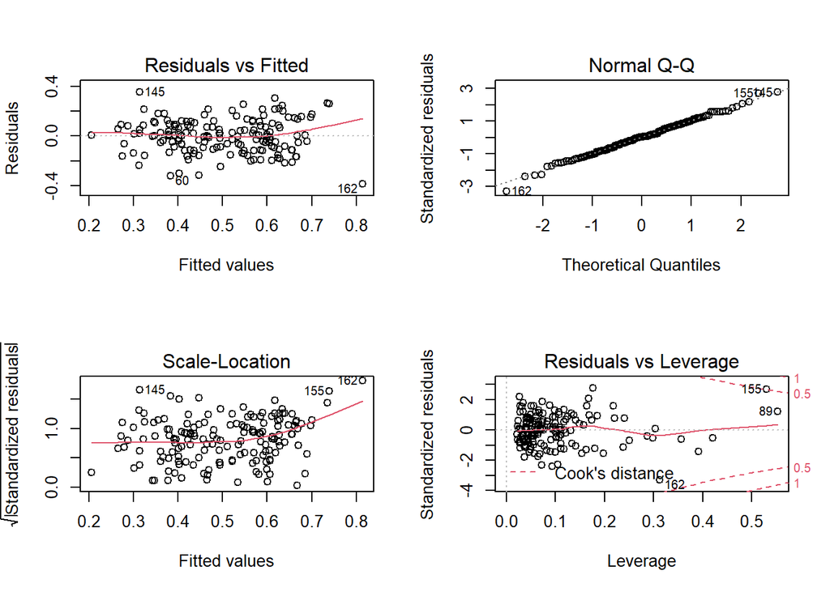

```r
par(mfrow=c(2,2))
plot(m3)
```

Conforme o gráfico abaixo, não há pontos a retirar.

```r
par(mfrow=c(1,1))
set.seed(2014)
hnp(m3,how.many.out = TRUE,print.on = TRUE)# Indica que pontos precisam ser retirados
```

```
## Gaussian model (lm object)
```

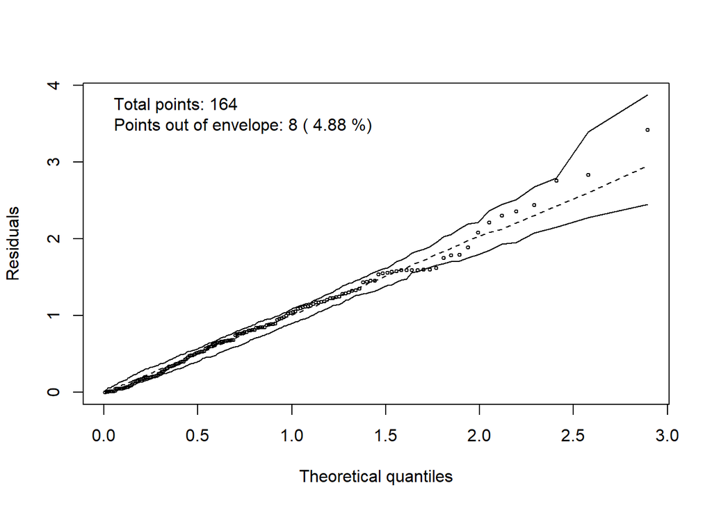

Com relação a tais pontos de dados, os seguintes parâmetros devem ser considerados. Devem ser removidos: 1- Os pontos de dados com resíduos padronizados> 3,29 2- os pontos de dados com valores D de Cook> 1  
3- os pontos de dados com valores de alavancagem 3 ( k + 1 ) / n (k = Número de preditores, N = Número de casos no modelo)

Ademais não pode haver autocorrelação entre os preditores. Isso significa que as variáveis independentes não podem ser correlacionadas consigo mesmas (por exemplo, porque os pontos de dados vêm do mesmo sujeito). Se houver autocorrelação entre os preditores, então, um Projeto de Medidas Repetidas ou um modelo (hierárquico) de efeitos mistos deve ser implementado.

Quanto à multicolinearidade, os preditores não podem se correlacionar substancialmente entre si. Se um modelo contém preditores com fatores de inflação de variância (VIF)> 10, o modelo não é confiável (Myers 1990 ) e os preditores que causam esses VIFs devem ser removidos.

```r
mlrdata=df_menor_out
mlrdata$residuals <- resid(m3)
mlrdata$standardized.residuals <- rstandard(m3)
mlrdata$studentized.residuals <- rstudent(m3)
mlrdata$cooks.distance <- cooks.distance(m3)
mlrdata$dffit <- dffits(m3)
mlrdata$leverage <- hatvalues(m3)
mlrdata$covariance.ratios <- covratio(m3)
mlrdata$fitted <- m3$fitted.values
```

Agora podemos usar essas estatísticas de diagnóstico para criar gráficos de diagnóstico mais precisos.

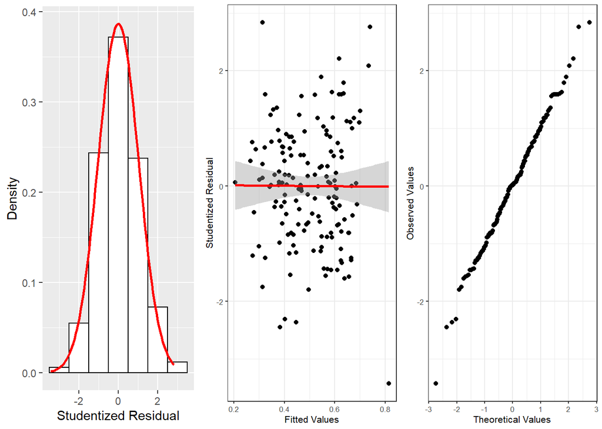

```r
# plot 5
p5 <- ggplot(mlrdata,
             aes(studentized.residuals)) +
  theme(legend.position = "none") +
  theme_set(theme_bw(base_size = 8))+
  geom_histogram(aes(y=..density..),
                 binwidth = 1,
                 colour="black",
                 fill="white") +
  labs(x = "Studentized Residual", y = "Density") +
  stat_function(fun = dnorm,
                args = list(mean = mean(mlrdata$studentized.residuals, na.rm = TRUE),
                            sd = sd(mlrdata$studentized.residuals, na.rm = TRUE)),
                colour = "red", size = 1)
# plot 6
p6 <- ggplot(mlrdata, aes(fitted, studentized.residuals)) +
  geom_point() +
  geom_smooth(method = "lm", colour = "Red")+
  theme_bw(base_size = 8)+
  labs(x = "Fitted Values",
       y = "Studentized Residual")
# plot 7
p7 <- qplot(sample = mlrdata$studentized.residuals, stat="qq") +
  theme_bw(base_size = 8) +
  labs(x = "Theoretical Values",
       y = "Observed Values")
grid.arrange(p5, p6, p7, nrow = 1)
```

Teste de autocorrelação

```r
dwt(m3)
```

```
##  lag Autocorrelation D-W Statistic p-value
##    1      0.01112499      1.973389    0.66
##  Alternative hypothesis: rho != 0
```

Teste de multicolinearidade

```r
vif(m3)
```

```
##                       GVIF Df GVIF^(1/(2*Df))
## Presidente     5445.955526  3        4.194489
## PWR               6.214498  1        2.492889
## AFF               7.945913  1        2.818850
## ACH               3.653831  1        1.911500
## Presidente:ACH  918.045528  3        3.117530
## Presidente:AFF  525.115259  3        2.840376
## Presidente:PWR  197.948156  3        2.414118
```

```r
mean(vif(m3))
```

```
## [1] 339.9842
```

O valor do Vif não deve ultrapassar 10 e o Vif médio não deve exceder 1, portanto, o modelo carece de robustez por apresentar alta multicolinearidade.

Comparação entre modelo final e modelo base para testar se o modelo final supera significativamente o modelo de base.

```r
#compare baseline- and minimal adequate model
m0=lm(P1~1, data=df_menor)
Anova(m0, m3, type = "III")
```

```
## Anova Table (Type III tests)
##
## Response: P1
##             Sum Sq  Df F value    Pr(>F)
## (Intercept) 42.779   1  2161.2 < 2.2e-16 ***
## Residuals    2.930 148
## ---
## Signif. codes:  0 '***' 0.001 '**' 0.01 '*' 0.05 '.' 0.1 ' ' 1
```

Comparação entre os três modelos

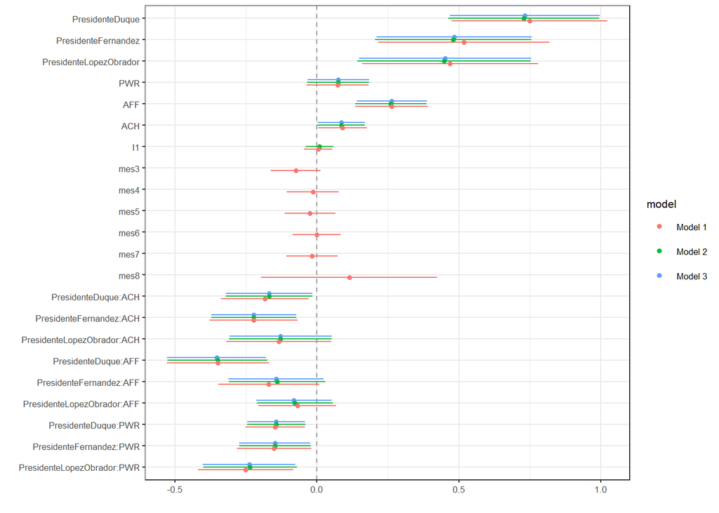

```r
dwplot(list(m1,
            m2,
            m3),
vline = geom_vline(xintercept = 0, colour = "grey60", linetype = 2))
```

Os resultados da análise de regressão realizada acima podem ser resumidos da seguinte forma: Uma regressão linear múltipla foi ajustada aos dados usando um procedimento automatizado, passo a passo, baseado em AIC (Akaike’s Information Criterion) e um baseado na proposta de Collet (1994). Com o ajuste do modelo chegou-se a um modelo final dado pela proposta de collet. Durante o diagnóstico do modelo, outliers foram detectados e removidos. Diagnósticos adicionais encontraram alguns problemas após a remoção desses outiliers (após o reajuste do modelo), chamando a atenção para o problema mais grave que foi a detecção de multicolinearidade. O modelo de regressão adequado final é baseado em 164 observações e tem um desempenho significativamente melhor do que um modelo de base (R2 ajustado : 0,393, estatística F (15, 148): 8.040***, AIC: -628), superior ao AIC inicial de -605 do modelo sem retirada de outilier e superior também ao AIC do modelo selecionado por stepwise (-607).

Se o Presidente for o Bolsonaro

Para ACH: tem -se o modelo P1=β0+β1ACH em que é dados por β0=0,0427 e β1=12,90, de forma que, há um acréscimo de 0,1032 em média em P1 para cada acréscimo médio de 0.008 em ACH.

Para AFF: tem -se o modelo P1=β0+β1AFF em que é dados por β0=0,0427 e β1=21,88 há um acréscimo de 0,26 em P1 para cada acréscimo médio de 0,012 em AFF.

Para PWR: tem -se o modelo P1=β0+β1PWR em que é dados por β0=0,0427 e β1=7,62 há um acréscimo de 0,0609 em P1 para cada acréscimo médio de 0,008 em PWR.

Se o Presidente for o Duque

Para AFF: tem -se o modelo P1=β0+β1AFF em que é dados por β0=0,77 e β1=-2,58 há um decréscimo de -0,0306 em P1 para cada acréscimo médio de 0,012 em AFF.

Se o Presidente for o Fernandez

Para ACH: tem -se o modelo P1=β0+β1ACH em que é dados por β0=0,5263 e β1=-14,54, de forma que, há um decréscimo de -0,1163 em média em P1 para cada acréscimo médio de 0.008 em ACH.

Para AFF: tem -se o modelo P1=β0+β1AFF em que é dados por β0=0,5263 e β1=10,87 há um acréscimo de 0,1304 em P1 para cada acréscimo médio de 0,012 em AFF.

Se o Presidente for o Lopes Obrador

Para ACH: tem -se o modelo P1=β0+β1ACH em que é dados por β0=0,4942 e β1=-5,83, de forma que, há um decréscimo de -0,0466 em média em P1 para cada acréscimo médio de 0.008 em ACH.

Para AFF: tem -se o modelo P1=β0+β1AFF em que é dados por β0=0,4942 e β1=11,99 há um acréscimo de 0,1438 em P1 para cada acréscimo médio de 0,012 em AFF.

*Teste para comparação de dois coeficientes de inclinação*

Pode ser realizado de acordo com Paternoster et al.(1998) [Z=(beta1-beta2)/sqrt(SEb1²+SEb2²)], os erros quadráticos são combinados.

Para Bolsonaro

*ACH vs AFF*

```r
beta1=12.90
beta2=21.88
SEb1=6.29
SEb2=5.14
Z=(beta1-beta2)/sqrt(SEb1^2+SEb2^2)
Z
```

```
## [1] -1.105498
```

```r
Z=abs(Z)
1-pnorm(Z)
```

```
## [1] 0.1344719
```

não difere

*ACH vs PWR*

```r
beta1=12.90
beta2=7.62
SEb1=6.29
SEb2=5.54
Z=(beta1-beta2)/sqrt(SEb1^2+SEb2^2)
Z
```

```
## [1] 0.6299312
```

```r
1-pnorm(Z)
```

```
## [1] 0.2643698
```

não difere

*AFF vs PWR*

```r
beta1=21.88
beta2=7.62
SEb1=5.14
SEb2=5.54
Z=(beta1-beta2)/sqrt(SEb1^2+SEb2^2)
Z
```

```
## [1] 1.886943
```

```r
1-pnorm(Z)
```

```
## [1] 0.02958397
```

difere

Para Duque

*ACH vs AFF*

```r
beta1=-5.81
beta2=-2.58
SEb1=(8.53+6.29)/2
SEb2=(5.14+6.14)/2
Z=(beta1-beta2)/sqrt(SEb1^2+SEb2^2)
Z
```

```
## [1] -0.3468555
```

```r
Z=abs(Z)
1-pnorm(Z)
```

```
## [1] 0.3643499
```

não difere

*ACH vs PWR*

```r
beta1=-5.81
beta2=-14.44
SEb1=(8.53+6.29)/2
SEb2=(5.54+8.14)/2
Z=(beta1-beta2)/sqrt(SEb1^2+SEb2^2)
Z
```

```
## [1] 0.8557832
```

```r
1-pnorm(Z)
```

```
## [1] 0.1960588
```

não difere

*AFF vs PWR*

```r
beta1=-2.51
beta2=-14.44
SEb1=(8.53+6.29)/2
SEb2=(5.54+8.14)/2
Z=(beta1-beta2)/sqrt(SEb1^2+SEb2^2)
Z
```

```
## [1] 1.183024
```

```r
1-pnorm(Z)
```

```
## [1] 0.1183999
```

não difere

Para Fernandez

*ACH vs AFF*

```r
beta1=-14.54
beta2=-10.87
SEb1=(9.32+6.29)/2
SEb2=(5.14+6.47)/2
Z=(beta1-beta2)/sqrt(SEb1^2+SEb2^2)
Z
```

```
## [1] -0.3772973
```

```r
Z=abs(Z)
1-pnorm(Z)
```

```
## [1] 0.3529764
```

não difere

*ACH vs PWR*

```r
beta1=-14.54
beta2=-10.02
SEb1=(9.32+6.29)/2
SEb2=(5.54+7.56)/2
Z=(beta1-beta2)/sqrt(SEb1^2+SEb2^2)
Z
```

```
## [1] -0.4436054
```

```r
Z=abs(Z)
1-pnorm(Z)
```

```
## [1] 0.328664
```

não difere

*AFF vs PWR*

```r
beta1=10.87
beta2=-10.02
SEb1=(5.14+6.47)/2
SEb2=(5.54+7.56)/2
Z=(beta1-beta2)/sqrt(SEb1^2+SEb2^2)
Z
```

```
## [1] 2.386836
```

```r
1-pnorm(Z)
```

```
## [1] 0.008497037
```

difere

Para Lopez Obrador

*ACH vs AFF*

```r
beta1=-5.83
beta2=11.99
SEb1=(13.33+6.29)/2
SEb2=(5.14+8.16)/2
Z=(beta1-beta2)/sqrt(SEb1^2+SEb2^2)
Z
```

```
## [1] -1.503604
```

```r
Z=abs(Z)
1-pnorm(Z)
```

```
## [1] 0.06634165
```

não difere

*ACH vs PWR*

```r
beta1=-5.83
beta2=-14.44
SEb1=(13.33+6.29)/2
SEb2=(5.54+6.99)/2
Z=(beta1-beta2)/sqrt(SEb1^2+SEb2^2)
Z
```

```
## [1] 0.7396997
```

```r
1-pnorm(Z)
```

```
## [1] 0.2297411
```

```r
## [1] 0.2297411
```

não difere

*AFF vs PWR*

```r
beta1=11.99
beta2=-14.44
SEb2=(5.14+8.16)/2
SEb2=(5.54+6.99)/2
Z=(beta1-beta2)/sqrt(SEb1^2+SEb2^2)
Z
```

```
## [1] 2.270646
```

```r
1-pnorm(Z)
```

```
## [1] 0.01158421
```

difere

```r
#teste Kruskal-Walis para comparação de grupos com dados não paramétricos
kruskal.test(ACH ~ Presidente, data= df_menor_out)
```

```
##
##  Kruskal-Wallis rank sum test
##
## data:  ACH by Presidente
## Kruskal-Wallis chi-squared = 7.5872, df = 3, p-value = 0.05536
```

```r
kruskal.test(AFF ~ Presidente, data= df_menor_out)
```

```
##
##  Kruskal-Wallis rank sum test
##
## data:  AFF by Presidente
## Kruskal-Wallis chi-squared = 45.999, df = 3, p-value = 5.676e-10
```

```r
kruskal.test(PWR ~ Presidente, data= df_menor_out)
```

```
##
##  Kruskal-Wallis rank sum test
##
## data:  PWR by Presidente
## Kruskal-Wallis chi-squared = 47.034, df = 3, p-value = 3.417e-10
```

No teste de Kruskal para ACH no grupo Presidente, não há diferença entre as medianas, mas está no limite com p-valor 0,05536. No teste de Kruskal para AFF no grupo Presidente, há diferença entre as medianas, com p-valor menor que 0,05. No teste de Kruskal para PWR no grupo Presidente, há diferença entre as medianas, com p-valor menor que 0,05.

```r
#teste post-hoc
dunn_test(ACH ~ Presidente, data = df_menor, p.adjust.method = "bonferroni")
```

```
## # A tibble: 6 x 9
##   .y.   group1    group2          n1    n2 statistic       p  p.adj p.adj.signif
## * <chr> <chr>     <chr>        <int> <int>     <dbl>   <dbl>  <dbl> <chr>
## 1 ACH   Bolsonaro Duque           27    54     1.20  0.231   1      ns
## 2 ACH   Bolsonaro Fernandez       27    38     0.695 0.487   1      ns
## 3 ACH   Bolsonaro LopezObrador    27    51    -0.929 0.353   1      ns
## 4 ACH   Duque     Fernandez       54    38    -0.506 0.613   1      ns
## 5 ACH   Duque     LopezObrador    54    51    -2.58  0.00997 0.0598 ns
## 6 ACH   Fernandez LopezObrador    38    51    -1.85  0.0646  0.388  ns
```

```r
dunn_test(AFF ~ Presidente, data = df_menor, p.adjust.method = "bonferroni")
```

```
## # A tibble: 6 x 9
##   .y.   group1   group2      n1    n2 statistic         p     p.adj p.adj.signif
## * <chr> <chr>    <chr>    <int> <int>     <dbl>     <dbl>     <dbl> <chr>
## 1 AFF   Bolsona~ Duque       27    54    -1.16    2.46e-1   1.00e+0 ns
## 2 AFF   Bolsona~ Fernand~    27    38    -0.930   3.52e-1   1.00e+0 ns
## 3 AFF   Bolsona~ LopezOb~    27    51    -5.66    1.47e-8   8.84e-8 ****
## 4 AFF   Duque    Fernand~    54    38     0.186   8.52e-1   1.00e+0 ns
## 5 AFF   Duque    LopezOb~    54    51    -5.50    3.72e-8   2.23e-7 ****
## 6 AFF   Fernand~ LopezOb~    38    51    -5.20    2.01e-7   1.20e-6 ****
```

```r
dunn_test(PWR ~ Presidente, data = df_menor, p.adjust.method = "bonferroni")
```

```
## # A tibble: 6 x 9
##   .y.   group1   group2        n1    n2 statistic        p    p.adj p.adj.signif
## * <chr> <chr>    <chr>      <int> <int>     <dbl>    <dbl>    <dbl> <chr>
## 1 PWR   Bolsona~ Duque         27    54    -3.57  3.61e- 4 2.17e- 3 **
## 2 PWR   Bolsona~ Fernandez     27    38    -0.324 7.46e- 1 1.00e+ 0 ns
## 3 PWR   Bolsona~ LopezObra~    27    51     2.30  2.12e- 2 1.27e- 1 ns
## 4 PWR   Duque    Fernandez     54    38     3.59  3.36e- 4 2.02e- 3 **
## 5 PWR   Duque    LopezObra~    54    51     7.11  1.13e-12 6.77e-12 ****
## 6 PWR   Fernand~ LopezObra~    38    51     2.94  3.29e- 3 1.98e- 2 *
```

```r
#Análise descritiva dos dados

df_menor_out %>% group_by(Presidente) %>%
  get_summary_stats(ACH, AFF, PWR, type = "median_iqr")
```

```
## # A tibble: 12 x 5
##    Presidente   variable     n median   iqr
##    <fct>        <chr>    <dbl>  <dbl> <dbl>
##  1 Bolsonaro    ACH         25  0.008 0.004
##  2 Bolsonaro    AFF         25  0.016 0.008
##  3 Bolsonaro    PWR         25  0.008 0.002
##  4 Duque        ACH         51  0.009 0.005
##  5 Duque        AFF         51  0.011 0.008
##  6 Duque        PWR         51  0.005 0.003
##  7 Fernandez    ACH         37  0.008 0.005
##  8 Fernandez    AFF         37  0.013 0.008
##  9 Fernandez    PWR         37  0.008 0.005
## 10 LopezObrador ACH         51  0.007 0.002
## 11 LopezObrador AFF         51  0.008 0.003
## 12 LopezObrador PWR         51  0.011 0.006
```

*Análise descritiva*

Para Bolsonaro, a mediana ACH = PWR = 0,008, a mediana AFF= 0,016;

Para Duque, a mediana ACH = 0,009, a mediana PWR = 0,005, a mediana AFF= 0,011;

Para Fernandez, mediana ACH = PWR = 0,008, a mediana AFF= 0,013;

Para Lopez Obrador, a mediana ACH = 0,007, a mediana PWR = 0,011, a mediana AFF= 0,008.

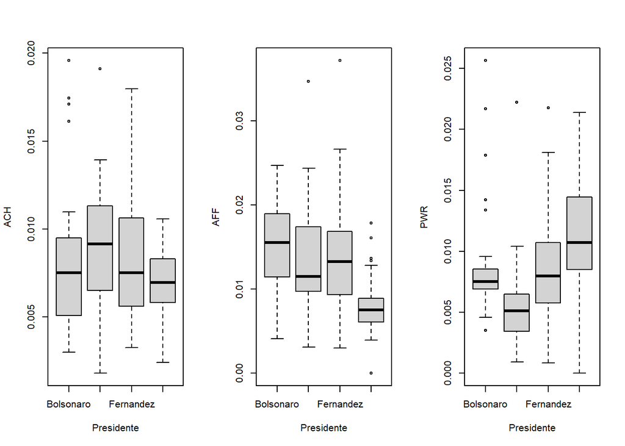

```r
# Visualização dos dados
par(mfrow=c(1,3))
boxplot(ACH ~ Presidente, data = df_menor_out)
boxplot(AFF ~ Presidente, data = df_menor_out)
boxplot(PWR ~ Presidente, data = df_menor_out)
```

O teste de Kruskal-Walis corroborou o achado da regressão e das diferenças dos betas. Lembrando que essas variáveis ACH, AFF e PWR possuem a mesma unidade de frequência de palavras.